# L01 Introduction

Data Visualization (STAT 302)

INSTRUCTIONS

## Goals

1. Ensure software for this course is properly installed and functional
2. Understand the importance of visualization
3. Develop and follow a proper workflow
4. Construct and explore a few plots using `ggplot2`
5. Add layers to a plot that include title, axis, and pre-set themes

**Don’t worry if you cannot do everything here by yourself.** You are just getting started and the learning curve is steep, but remember that the instructional team and your classmates will be there to provide support. Persevere and put forth an honest effort and this course will payoff.

**Organization is important!**

1. All packages should always be loaded at the TOP of the document.
2. All data should be in your `/data` subdirectory. Data loading should go at the top of the document under the libraries.

## Tasks

Complete the following tasks. For many of these you’ll need to simply **indicate that you have completed the task**.

### Task 1

Download and install [R Software](https://cran.rstudio.com/).

### Task 2

1. Download and install [RStudio](https://www.rstudio.com/products/rstudio/download4/).
2. Open RStudio and ensure it and R have been properly installed.
3. Go to **Tools** > **Global Options** and change the two indicated settings below and click **Apply**. Your other options are likely different than what is pictured. This is okay and we suggest you leave them as is until you become more familiar with RStudio.

[figure not shown]

### Task 3

Take some time to explore the [Quarto](https://quarto.org/) and [ggplot2](https://ggplot2.tidyverse.org/index.html) websites. We suggest bookmarking them because they will be extremely useful references.

We highly recommend reading through the [Tutorial: Hello, Quarto](https://quarto.org/docs/get-started/hello/rstudio.html).

### Task 4

Install the following packages:

- `tidyverse`, actually it is a collection/universe of packages being installed
- `skimr`
- `devtools`

### Task 5

1. Download `L01_introduction.zip` from Canvas.
2. Unzip the file and place the `data_vis_labs` directory where you would like to keep all of your lab work for this course.
3. Open RStudio and create a project folder for this *existing directory*.
4. Rename `template_L01.qmd` to your `Lastname_Firstname_L01.qmd`
5. Render the file with `Cmd/Ctrl + Shift + K` or click the Render button.

### Task 6 (optional)

If you are new to RStudio we strongly recommend reading through Chapters 1-4 of the [Stat 202 text book](https://nustat.github.io/intro-stat-data-sci/)

## Exercise 1

Let’s delve into why data visualizations are important.

### Visualization 1

Read the following article and answer the following questions.

[bars_vs_grocery_stores](https://flowingdata.com/2014/05/29/bars-versus-grocery-stores-around-the-world/)

1. List one thing you learned from the article?

2. How did the main visualization (United States) enhance the article?

3. List at least one thing you liked about the [United States] graphic and one thing you think could be improved.

### Visualization 2

Open this [dashboard](https://edgarruiz.shinyapps.io/db-dashboard/) and answer the following questions.

1. What story is this dashboard telling and how do the visualizations enhance that?

2. What might a dashboard provide that a static graphic cannot.

## Exercise 2

Let’s look at some interesting patterns in the history of LEGO! We’ll be using data from the [`lego` package](https://github.com/seankross/lego) located `data/legosets.rda`.

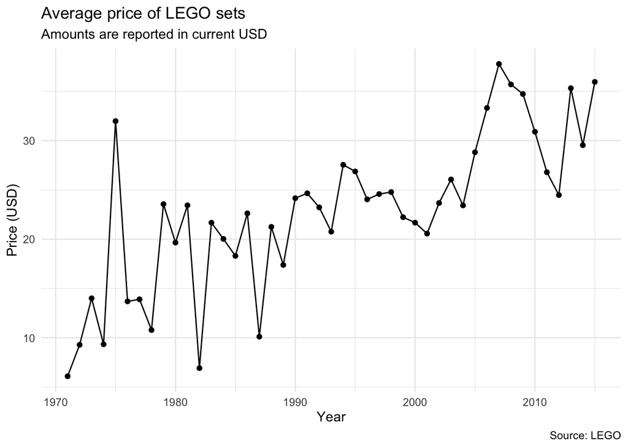

## Exercise 3

Let’s explore how many unique themes LEGO now offers.

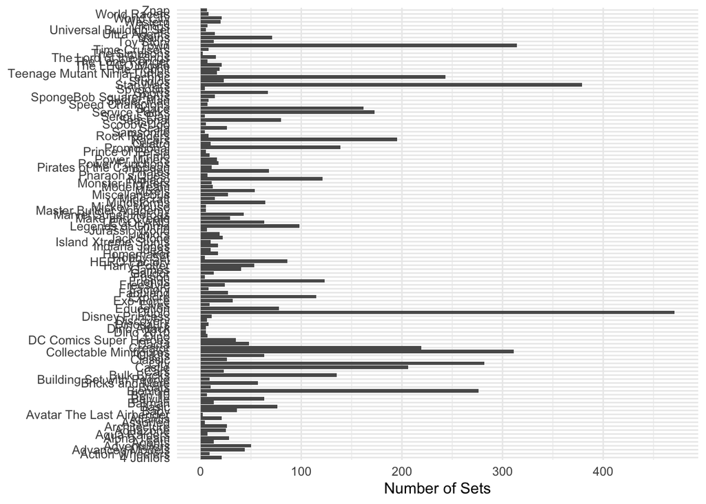

What is bad/ugly about the plot above?

Now remake the plot BUT with the improvements addressing the issues you noted above.

## Exercise 4

Now you try, let’s look at how the number of pieces per set has changed over time. Because Duplo sets are much smaller (since they’re designed for toddlers), we made a special indicator variable for them shown in the code below.

```r
pieces_per_year <- legosets %>%
  # new indicator variable
  mutate(Duplo = ifelse(Theme == "Duplo", "Duplo", "Lego")) %>%
  # group_by() both year and Duplo
  # summarize() mean pieces
```

Use an appropriate graph to plot the number of pieces over time. Have either separate lines or separate plots for the Duplo and Lego categories. Be sure the title, x-axis, and y-axis are properly labeled. Add a pre-set theme to make the background look nicer.

What trends do you notice in the plots? Are you surprised by the plots?